# Project 2: Modeling Home Prices

Bowen Jones

Last compiled: 2018-05-03

```
'data.frame':   17384 obs. of  21 variables:
 $ id           : num  7.13e+09 6.41e+09 5.63e+09 2.49e+09 1.95e+09 ...
 $ date         : Factor w/ 368 levels "20140502T000000",..: 164 219 287 219 280 11 57 250 336 302 ...
 $ price        : num  221900 538000 180000 604000 510000 ...
 $ bedrooms     : int  3 3 2 4 3 4 3 3 3 3 ...
 $ bathrooms    : num  1 2.25 1 3 2 4.5 2.25 1.5 1 2.5 ...
 $ sqft_living  : int  1180 2570 770 1960 1680 5420 1715 1060 1780 1890 ...
 $ sqft_lot     : int  5650 7242 10000 5000 8080 101930 6819 9711 7470 6560 ...
 $ floors       : num  1 2 1 1 1 1 2 1 1 2 ...
 $ waterfront   : int  0 0 0 0 0 0 0 0 0 0 ...
 $ view         : int  0 0 0 0 0 0 0 0 0 0 ...
 $ condition    : int  3 3 3 5 3 3 3 3 3 3 ...
 $ grade        : int  7 7 6 7 8 11 7 7 7 7 ...
 $ sqft_above   : int  1180 2170 770 1050 1680 3890 1715 1060 1050 1890 ...
 $ sqft_basement: int  0 400 0 910 0 1530 0 0 730 0 ...
 $ yr_built     : int  1955 1951 1933 1965 1987 2001 1995 1963 1960 2003 ...
 $ yr_renovated : int  0 1991 0 0 0 0 0 0 0 0 ...
 $ zipcode      : Factor w/ 70 levels "98001","98002",..: 67 56 17 59 38 30 3 69 61 24 ...
 $ lat          : num  47.5 47.7 47.7 47.5 47.6 ...
 $ long         : num  -122 -122 -122 -122 -122 ...
 $ sqft_living15: int  1340 1690 2720 1360 1800 4760 2238 1650 1780 2390 ...
 $ sqft_lot15   : int  5650 7639 8062 5000 7503 101930 6819 9711 8113 7570 ...
```

Variable descriptions were obtained from King County, Department of Assessments. All feature engineering should be done in the first code chunks of your document.

- `id` - Unique ID for each home sold
- `date` - Date of the home sale
- `price` - Price of each home sold
- `bedrooms` - Number of bedrooms
- `bathrooms` - Number of bathrooms, where .5 accounts for a room with a toilet but no shower
- `sqft_living` - Square footage of the apartments interior living space
- `sqft_lot` - Square footage of the land space
- `floors` - Number of floors
- `waterfront` - A dummy variable for whether the apartment was overlooking the waterfront or not * 1’s represent a waterfront property, 0’s represent a non-waterfront property
- `view` - An index from 0 to 4 of how good the view of the property was, 0 - lowest, 4 - highest
- `condition` - An index from 1 to 5 on the condition of the apartment, 1 - lowest, 4 - highest
- `grade` - An index from 1 to 13, where 1-3 falls short of building construction and design, 7 has an average level of construction and design, and 11-13 have a high quality level of construction and design.
- `sqft_above` - The square footage of the interior housing space that is above ground level
- `sqft_basement` - The square footage of the interior housing space that is below ground level
- `yr_built` - The year the house was initially built
- `yr_renovated` - The year of the house’s last renovation
- `zipcode` - What zipcode area the house is in
- `lat` - Latitude
- `long` - Longitude
- `sqft_living15` - The square footage of interior housing living space for the nearest 15 neighbors
- `sqft_lot15` - The square footage of the land lots of the nearest 15 neighbors

# Exploring and Wrangling

[*Modeling Home Prices Using Realtor Data*](https://ww2.amstat.org/publications/jse/v16n2/datasets.pardoe.html) offers a thoughtful and intelligent approach to predicting the price of homes using relevant variables regarding the home. Since we share this objective, I directly follow the steps taken by Pardoe in many places throughout this project.

## Variables to explore:

- `sqft_living`, `sqft_above` & `sqft_basement`
- `sqft_lot` & `sqft_lot15`
- `yr_built`

To assess the validity of any variable transformation performed, I’ll refer to the correlation coefficient *r* which reports the strength of the relationship between two variables. I’ll compare the r value between `price` and the variable before transformation to the r value between `price` and the variable after transformation.

### `sqft_living`, `sqft_above`, `sqft_basement`

There seems to be a lot of redundant information stored between the `sqft_living`, `sqft_above` and `sqft_basement` columns. If possible, I’d like to consolidate these variables and eliminate any superfluous information.

- Create a simple `basement` column that returns a `1` if `sqft_basement > 0` and compare to `sqft_basement`

```r
housedata$sqft_basement <- as.numeric(housedata$sqft_basement)
housedata$basement <- ifelse(housedata$sqft_basement > 0, 1, 0)
```

After creating the `basement` variable, the r values between `price` and `sqft_basement`/`basement` decreased from 0.3312296 to 0.1832654. Therefore, this transformation was ineffective and shall be removed.

### `sqft_lot` & `sqft_lot15`

In the [*Modeling Homes*](https://ww2.amstat.org/publications/jse/v16n2/datasets.pardoe.html) article, Pardoe explains the common practice of realtors using “lot size ‘categories’” when pricing homes instead of the raw ft$^2$ value. If this is truly common practice, then recoding the data from raw ft$^2$ to lot size categories should improve the relationship between `price` and land size.

- Create `lotsize` and `lotsize15` from `sqft_lot` and `sqft_lot15`

```r
housedata <- housedata %>%
  mutate(lotsize = cut(sqft_lot, breaks=c(-Inf, 3000, 5000, 7000, 10000, 15000, 20000, 43560, 130680, 217800, 435600, Inf), labels=c(1, 2, 3, 4, 5, 6, 7, 8, 9, 10, 11)))
housedata$lotsize <- as.numeric(housedata$lotsize)

# Lotsize15
housedata <- housedata %>%
  mutate(lotsize15 = cut(sqft_lot15, breaks=c(-Inf, 3000, 5000, 7000, 10000, 15000, 20000, 43560, 130680, 217800, 435600, Inf), labels=c(1, 2, 3, 4, 5, 6, 7, 8, 9, 10, 11)))
housedata$lotsize15 <- as.numeric(housedata$lotsize15)
```

Creating the `lotsize` and `lotsize15` variables increased the $r$ value from 0.0882381 and 0.0808064 to 0.1662823 and 0.1527959 respectively. Remove `sqft_lot` and `sqft_lot15` to reduce redundancy.

### `yr_built` & `age`

```r
mean(housedata$yr_built)
```

```
[1] 1971.153
```

```r
housedata <- housedata %>%
  mutate(age = (1971 - as.numeric(yr_built))/10) # Decades since 1971 (mean yr_built)
```

Here, I created an `age` variable which indicates the age of the home in decades since 1971 (mean `yr_built`). The r value changed from 0.0525221 to -0.0525221. While the creation of the `age` variable didn’t increase the r value, it made the data in the `yr_built` column available for linear regression. Remove `yr_built`.

## Final dataframe

| price | bedrooms | bathrooms | sqft_living | floors | waterfront | view | condition | grade | sqft_above |
| --- | --- | --- | --- | --- | --- | --- | --- | --- | --- |
| 221900 | 3 | 1 | 1180 | 1 | No | poor | average | 7 | 1180 |
| 538000 | 3 | 2.25 | 2570 | 2 | No | poor | average | 7 | 2170 |
| 180000 | 2 | 1 | 770 | 1 | No | poor | average | 6 | 770 |
| 604000 | 4 | 3 | 1960 | 1 | No | poor | very good | 7 | 1050 |
| 510000 | 3 | 2 | 1680 | 1 | No | poor | average | 8 | 1680 |
| 1225000 | 4 | 4.5 | 5420 | 1 | No | poor | average | 11 | 3890 |
| 257500 | 3 | 2.25 | 1715 | 2 | No | poor | average | 7 | 1715 |
| 291850 | 3 | 1.5 | 1060 | 1 | No | poor | average | 7 | 1060 |
| 229500 | 3 | 1 | 1780 | 1 | No | poor | average | 7 | 1050 |
| 323000 | 3 | 2.5 | 1890 | 2 | No | poor | average | 7 | 1890 |

[output cut: 17374 more lines]

## Verify updated dataframe

```
Analysis of Variance Table

Model 1: price ~ bedrooms + bathrooms + sqft_living + sqft_lot + floors +
    waterfront + view + condition + grade + sqft_above + sqft_basement +
    yr_built + yr_renovated + zipcode + lat + long + sqft_living15 +
    sqft_lot15
Model 2: price ~ bedrooms + bathrooms + sqft_living + floors + waterfront +
    view + condition + grade + sqft_above + sqft_basement + yr_renovated +
    zipcode + lat + long + sqft_living15 + lotsize + lotsize15 +
    age
  Res.Df        RSS Df  Sum of Sq      F    Pr(>F)
1  17298 4.5804e+14
2  17292 4.5376e+14  6 4.2815e+12 27.193 < 2.2e-16 ***
---
Signif. codes:  0 '***' 0.001 '**' 0.01 '*' 0.05 '.' 0.1 ' ' 1
```

Repeat all steps to form test dataframe.

# Subset Selection

Here, I will use a method known as *subset selection* to generate a model to predict `price` from other variables, and then improve upon it by performing nonlinear transformations and introducing interaction terms.

### Backwards Elimination

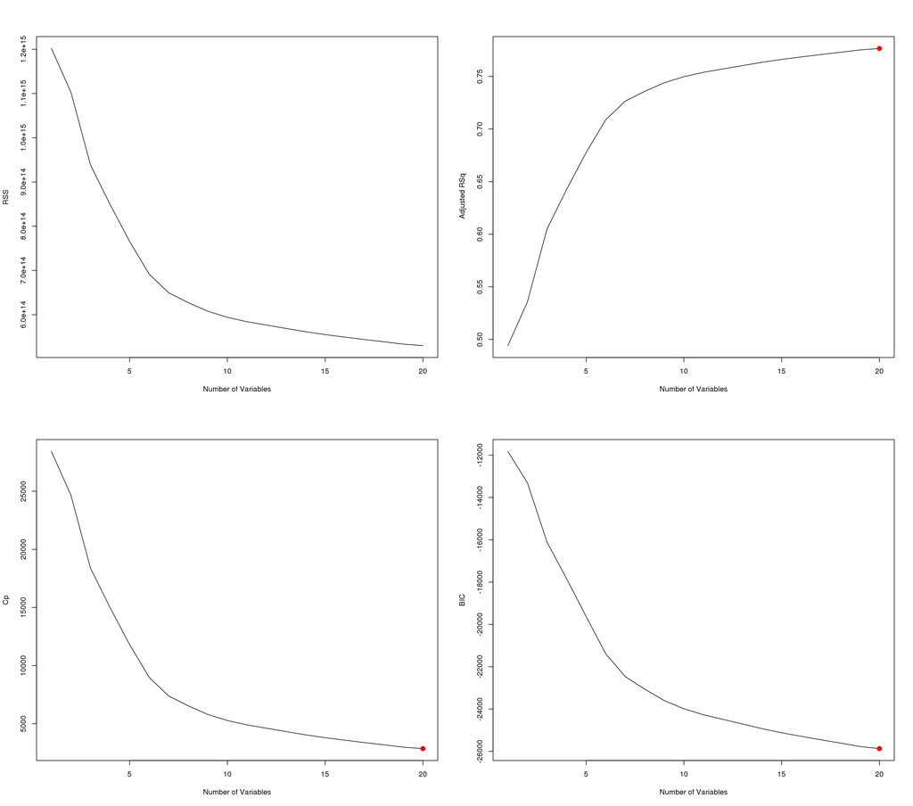

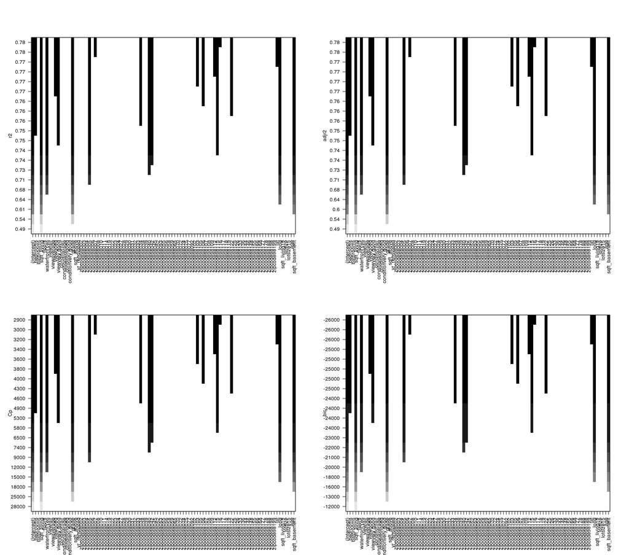

### Forward Selection

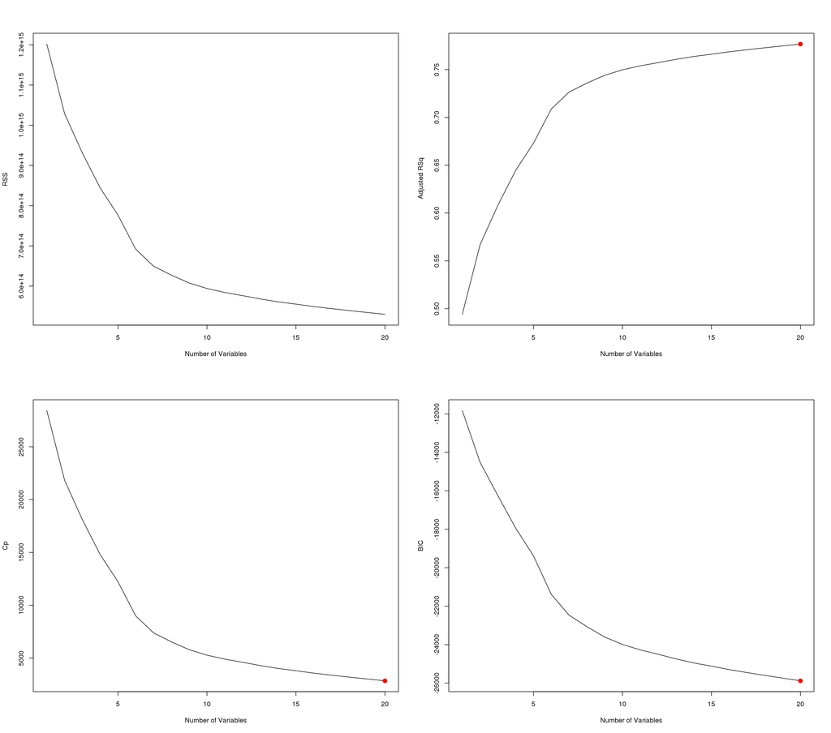

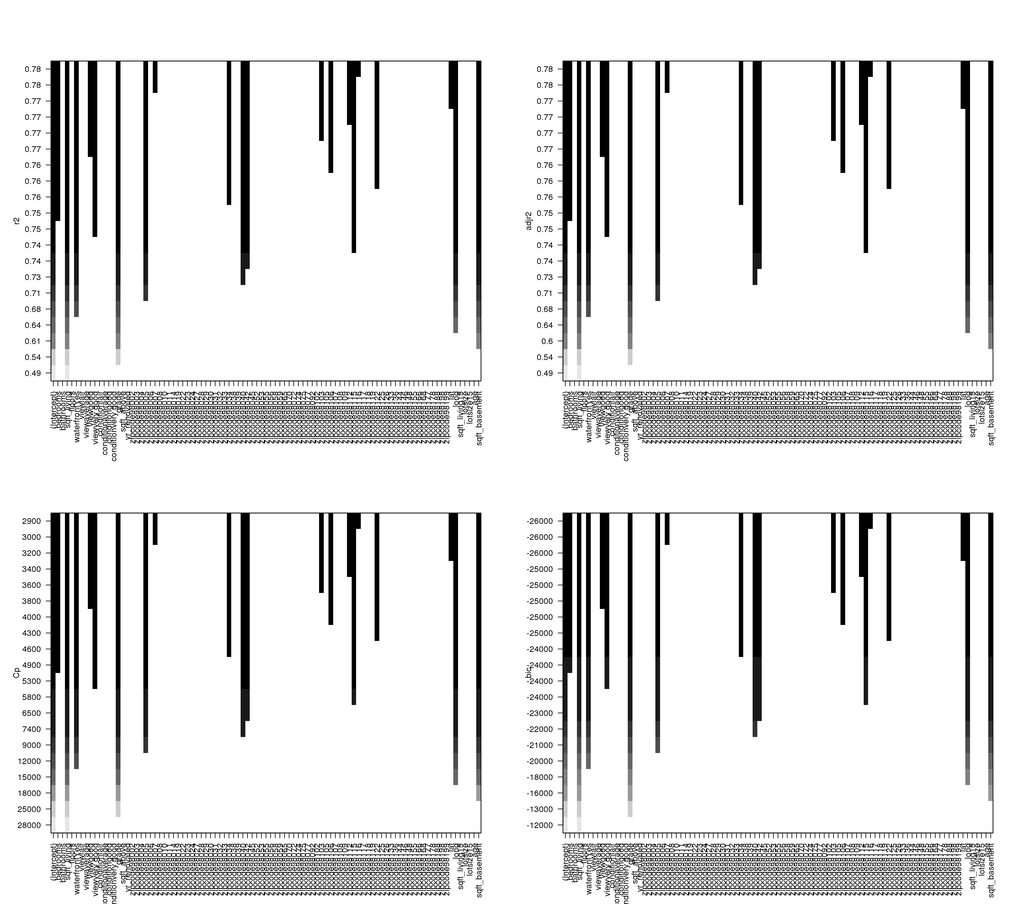

The set of plots for both methods of subset selection indicates that the same model would contain the highest $R^2$ value and the lowest $C_p$ and BIC values.

## Strengthening the model above

### Perform nonlinear transformations

I will begin by referring to the `residualPlots()` output to determine which predictors would benefit from a nonlinear transformation.

```
Call:
lm(formula = price ~ bedrooms + sqft_living + I(waterfront ==
    "Yes") + I(view == "good") + I(view == "very good") + grade +
    I(zipcode == 98005) + I(zipcode == 98007) + I(zipcode ==
    98034) + I(zipcode == 98040) + I(zipcode == 98042) + I(zipcode ==
    98103) + I(zipcode == 98106) + I(zipcode == 98112) + I(zipcode ==
    98115) + I(zipcode == 98116) + I(zipcode == 98122) + lat +
    long + sqft_basement + I(sqft_living^2) + I(grade^2) + I(sqft_basement^2),
    data = housedata)

Residuals:
     Min       1Q   Median       3Q      Max
-3790778   -89063   -10418    64356  2829843

Coefficients:
                             Estimate Std. Error t value Pr(>|t|)
(Intercept)                -4.566e+07  1.500e+06 -30.429  < 2e-16 ***
bedrooms                   -1.442e+03  2.116e+03  -0.682  0.49546
sqft_living                 9.209e+00  6.544e+00   1.407  0.15938
I(waterfront == "Yes")TRUE  5.583e+05  2.073e+04  26.925  < 2e-16 ***
I(view == "good")TRUE       1.322e+05  1.001e+04  13.202  < 2e-16 ***
I(view == "very good")TRUE  2.619e+05  1.514e+04  17.297  < 2e-16 ***
grade                      -2.544e+05  1.241e+04 -20.503  < 2e-16 ***
I(zipcode == 98005)TRUE     1.011e+05  1.686e+04   5.999 2.02e-09 ***
I(zipcode == 98007)TRUE     5.661e+04  1.782e+04   3.177  0.00149 **
I(zipcode == 98034)TRUE    -6.294e+04  9.403e+03  -6.693 2.25e-11 ***
I(zipcode == 98040)TRUE     3.279e+05  1.359e+04  24.127  < 2e-16 ***
I(zipcode == 98042)TRUE    -2.163e+04  9.617e+03  -2.249  0.02451 *
I(zipcode == 98103)TRUE     6.249e+04  9.242e+03   6.761 1.41e-11 ***
I(zipcode == 98106)TRUE    -7.189e+04  1.208e+04  -5.949 2.76e-09 ***
I(zipcode == 98112)TRUE     3.553e+05  1.326e+04  26.798  < 2e-16 ***
I(zipcode == 98115)TRUE     7.713e+04  9.120e+03   8.458  < 2e-16 ***
I(zipcode == 98116)TRUE     8.262e+04  1.211e+04   6.823 9.18e-12 ***
I(zipcode == 98122)TRUE     1.081e+05  1.292e+04   8.370  < 2e-16 ***
lat                         6.007e+05  1.149e+04  52.280  < 2e-16 ***
long                       -1.480e+05  1.175e+04 -12.595  < 2e-16 ***
sqft_basement               7.149e+01  8.256e+00   8.659  < 2e-16 ***
I(sqft_living^2)            2.794e-02  1.012e-03  27.607  < 2e-16 ***
I(grade^2)                  2.156e+04  7.748e+02  27.833  < 2e-16 ***
I(sqft_basement^2)         -4.746e-02  5.938e-03  -7.994 1.39e-15 ***
---
Signif. codes:  0 '***' 0.001 '**' 0.01 '*' 0.05 '.' 0.1 ' ' 1

Residual standard error: 191300 on 17360 degrees of freedom
Multiple R-squared:  0.7326,    Adjusted R-squared:  0.7323
F-statistic:  2068 on 23 and 17360 DF,  p-value: < 2.2e-16
```

### Introduce interaction terms

Here, I add interactions to the model to improve accuracy. One could infer that there is a relationship between `bedrooms` and `sqft_living`, and additionally between `sqft_basement` and `sqft_living`.

```
Call:
lm(formula = price ~ bedrooms + sqft_living + I(waterfront ==
    "Yes") + I(view == "good") + I(view == "very good") + grade +
    I(zipcode == 98005) + I(zipcode == 98007) + I(zipcode ==
    98034) + I(zipcode == 98040) + I(zipcode == 98042) + I(zipcode ==
    98103) + I(zipcode == 98106) + I(zipcode == 98112) + I(zipcode ==
    98115) + I(zipcode == 98116) + I(zipcode == 98122) + lat +
    long + sqft_basement + I(sqft_living^2) + I(grade^2) + I(sqft_basement^2) +
    bedrooms:sqft_living + sqft_living:sqft_basement + sqft_basement:I(sqft_living^2) +
    bedrooms:I(sqft_living^2) + I(sqft_living^2):I(sqft_basement^2),
    data = housedata)

Residuals:
     Min       1Q   Median       3Q      Max
-2364730   -88079   -10422    63804  2309151

Coefficients:
                                      Estimate Std. Error t value Pr(>|t|)
(Intercept)                         -4.637e+07  1.490e+06 -31.122  < 2e-16
bedrooms                            -3.079e+02  7.330e+03  -0.042  0.96649
sqft_living                         -5.327e+01  1.918e+01  -2.778  0.00547
I(waterfront == "Yes")TRUE           5.430e+05  2.057e+04  26.396  < 2e-16
I(view == "good")TRUE                1.247e+05  9.932e+03  12.556  < 2e-16
I(view == "very good")TRUE           2.617e+05  1.500e+04  17.442  < 2e-16
grade                               -2.411e+05  1.326e+04 -18.180  < 2e-16
I(zipcode == 98005)TRUE              1.044e+05  1.668e+04   6.260 3.95e-10
I(zipcode == 98007)TRUE              5.441e+04  1.763e+04   3.087  0.00203
I(zipcode == 98034)TRUE             -6.555e+04  9.314e+03  -7.037 2.04e-12
I(zipcode == 98040)TRUE              3.313e+05  1.347e+04  24.596  < 2e-16
I(zipcode == 98042)TRUE             -2.453e+04  9.516e+03  -2.578  0.00995
I(zipcode == 98103)TRUE              6.231e+04  9.149e+03   6.811 1.00e-11
I(zipcode == 98106)TRUE             -7.010e+04  1.196e+04  -5.860 4.72e-09
I(zipcode == 98112)TRUE              3.521e+05  1.315e+04  26.775  < 2e-16
I(zipcode == 98115)TRUE              7.874e+04  9.024e+03   8.725  < 2e-16
I(zipcode == 98116)TRUE              8.517e+04  1.198e+04   7.108 1.22e-12
I(zipcode == 98122)TRUE              1.099e+05  1.279e+04   8.593  < 2e-16
lat                                  6.085e+05  1.140e+04  53.353  < 2e-16
long                                -1.506e+05  1.165e+04 -12.926  < 2e-16
sqft_basement                        6.056e+01  1.911e+01   3.168  0.00154
I(sqft_living^2)                     4.889e-02  3.715e-03  13.158  < 2e-16
```

[output cut: 28 more lines]

```
sqft_basement                       **
I(sqft_living^2)                    ***
I(grade^2)                          ***
I(sqft_basement^2)                  ***
bedrooms:sqft_living                **
sqft_living:sqft_basement           **
sqft_basement:I(sqft_living^2)      ***
bedrooms:I(sqft_living^2)           ***
I(sqft_living^2):I(sqft_basement^2) ***
---
Signif. codes:  0 '***' 0.001 '**' 0.01 '*' 0.05 '.' 0.1 ' ' 1

Residual standard error: 189200 on 17355 degrees of freedom
Multiple R-squared:  0.7384,    Adjusted R-squared:  0.738
F-statistic:  1750 on 28 and 17355 DF,  p-value: < 2.2e-16
```

# Self-Selection

In the following sections, I begin with a full model that regresses `price` on to every available predictor. I will then proceed to strengthen the model by again performing nonlinear transformations and introducing interaction terms.

## Full model

```
Call:
lm(formula = price ~ ., data = housedata)

Residuals:
     Min       1Q   Median       3Q      Max
-1237318   -70270     -251    62652  4353961

Coefficients: (1 not defined because of singularities)
                     Estimate Std. Error t value Pr(>|t|)
(Intercept)        -3.198e+07  6.930e+06  -4.615 3.97e-06 ***
bedrooms           -3.083e+04  1.797e+03 -17.158  < 2e-16 ***
bathrooms           2.497e+04  2.967e+03   8.414  < 2e-16 ***
sqft_living         1.312e+02  4.000e+00  32.797  < 2e-16 ***
floors             -4.098e+04  3.646e+03 -11.239  < 2e-16 ***
waterfrontYes       5.836e+05  1.791e+04  32.585  < 2e-16 ***
viewfair            7.118e+04  1.037e+04   6.862 7.03e-12 ***
viewaverage         6.866e+04  6.174e+03  11.121  < 2e-16 ***
viewgood            1.413e+05  8.707e+03  16.226  < 2e-16 ***
viewvery good       3.165e+05  1.303e+04  24.292  < 2e-16 ***
conditionfair       6.766e+04  3.606e+04   1.876 0.060658 .
conditionaverage    5.029e+04  3.339e+04   1.506 0.132012
conditiongood       6.723e+04  3.339e+04   2.013 0.044084 *
conditionvery good  1.110e+05  3.361e+04   3.304 0.000955 ***
grade               5.957e+04  2.060e+03  28.918  < 2e-16 ***
sqft_above          7.802e+01  4.106e+00  19.000  < 2e-16 ***
sqft_basement              NA         NA      NA       NA
yr_renovated        1.458e+01  3.347e+00   4.357 1.33e-05 ***
zipcode98002        4.485e+04  1.638e+04   2.738 0.006189 **
zipcode98003       -1.868e+04  1.447e+04  -1.291 0.196572
zipcode98004        7.300e+05  2.646e+04  27.586  < 2e-16 ***
zipcode98005        2.357e+05  2.830e+04   8.329  < 2e-16 ***
zipcode98006        2.314e+05  2.305e+04  10.039  < 2e-16 ***
zipcode98007        1.976e+05  2.900e+04   6.813 9.86e-12 ***
zipcode98008        2.170e+05  2.768e+04   7.840 4.78e-15 ***
zipcode98010        9.536e+04  2.456e+04   3.883 0.000104 ***
zipcode98011        3.974e+04  3.618e+04   1.098 0.272024
zipcode98014        7.708e+04  3.992e+04   1.931 0.053535 .
zipcode98019        4.913e+04  3.891e+04   1.262 0.206811
zipcode98022        6.485e+04  2.164e+04   2.997 0.002734 **
zipcode98023       -5.325e+04  1.336e+04  -3.985 6.79e-05 ***
```

[output cut: 53 more lines]

```
zipcode98188        2.108e+03  2.047e+04   0.103 0.917964
zipcode98198       -2.470e+04  1.563e+04  -1.581 0.113960
zipcode98199        2.913e+05  2.847e+04  10.232  < 2e-16 ***
lat                 2.176e+05  7.147e+04   3.044 0.002336 **
long               -1.731e+05  5.105e+04  -3.390 0.000701 ***
sqft_living15       6.986e+00  3.269e+00   2.137 0.032636 *
lotsize             9.441e+03  1.656e+03   5.702 1.21e-08 ***
lotsize15          -1.917e+03  1.834e+03  -1.045 0.295975
age                 7.282e+03  7.492e+02   9.720  < 2e-16 ***
---
Signif. codes:  0 '***' 0.001 '**' 0.01 '*' 0.05 '.' 0.1 ' ' 1

Residual standard error: 162000 on 17292 degrees of freedom
Multiple R-squared:  0.809, Adjusted R-squared:  0.808
F-statistic: 804.9 on 91 and 17292 DF,  p-value: < 2.2e-16
```

### Perform nonlinear transformations

Again, I begin by referring to the `residualPlots()` output to determine which predictors would benefit from a nonlinear transformation.

```
Call:
lm(formula = price ~ bedrooms + bathrooms + sqft_living + floors +
    waterfront + view + condition + grade + sqft_above + sqft_basement +
    yr_renovated + zipcode + lat + long + sqft_living15 + lotsize +
    lotsize15 + age + I(bathrooms^2) + I(sqft_living^2) + I(grade^2) +
    I(sqft_above^2) + I(sqft_basement^2) + I(yr_renovated^2),
    data = housedata)

Residuals:
     Min       1Q   Median       3Q      Max
-3463192   -57252     2735    54593  2405534

Coefficients: (1 not defined because of singularities)
                     Estimate Std. Error t value Pr(>|t|)
(Intercept)        -4.033e+07  6.299e+06  -6.402 1.57e-10 ***
bedrooms           -5.166e+03  1.694e+03  -3.049 0.002300 **
bathrooms           1.757e+04  7.731e+03   2.273 0.023042 *
sqft_living        -1.745e+01  7.519e+00  -2.321 0.020297 *
floors             -2.908e+04  3.414e+03  -8.516  < 2e-16 ***
waterfrontYes       5.908e+05  1.630e+04  36.248  < 2e-16 ***
viewfair            7.641e+04  9.434e+03   8.099 5.89e-16 ***
viewaverage         6.422e+04  5.617e+03  11.432  < 2e-16 ***
viewgood            1.267e+05  7.933e+03  15.968  < 2e-16 ***
viewvery good       2.668e+05  1.191e+04  22.394  < 2e-16 ***
conditionfair       1.328e+05  3.283e+04   4.044 5.27e-05 ***
conditionaverage    1.520e+05  3.046e+04   4.991 6.08e-07 ***
conditiongood       1.797e+05  3.047e+04   5.896 3.79e-09 ***
conditionvery good  2.320e+05  3.068e+04   7.564 4.12e-14 ***
grade              -2.433e+05  1.045e+04 -23.282  < 2e-16 ***
sqft_above          8.348e+01  8.931e+00   9.348  < 2e-16 ***
sqft_basement              NA         NA      NA       NA
yr_renovated       -2.654e+03  3.508e+02  -7.566 4.04e-14 ***
zipcode98002        2.410e+04  1.489e+04   1.619 0.105552
zipcode98003       -1.535e+04  1.315e+04  -1.167 0.243110
zipcode98004        7.067e+05  2.405e+04  29.385  < 2e-16 ***
zipcode98005        2.562e+05  2.572e+04   9.962  < 2e-16 ***
zipcode98006        2.201e+05  2.095e+04  10.509  < 2e-16 ***
zipcode98007        2.158e+05  2.635e+04   8.189 2.82e-16 ***
zipcode98008        2.381e+05  2.516e+04   9.462  < 2e-16 ***
zipcode98010        1.130e+05  2.232e+04   5.063 4.16e-07 ***
```

[output cut: 64 more lines]

```
lotsize             1.104e+04  1.505e+03   7.333 2.35e-13 ***
lotsize15          -3.926e+03  1.668e+03  -2.354 0.018569 *
age                 2.289e+03  6.938e+02   3.300 0.000970 ***
I(bathrooms^2)      1.548e+03  1.524e+03   1.016 0.309825
I(sqft_living^2)    3.997e-02  1.565e-03  25.541  < 2e-16 ***
I(grade^2)          1.928e+04  6.427e+02  29.998  < 2e-16 ***
I(sqft_above^2)    -2.591e-02  2.027e-03 -12.781  < 2e-16 ***
I(sqft_basement^2) -7.125e-02  5.770e-03 -12.349  < 2e-16 ***
I(yr_renovated^2)   1.343e+00  1.758e-01   7.643 2.23e-14 ***
---
Signif. codes:  0 '***' 0.001 '**' 0.01 '*' 0.05 '.' 0.1 ' ' 1

Residual standard error: 147200 on 17286 degrees of freedom
Multiple R-squared:  0.8424,    Adjusted R-squared:  0.8415
F-statistic: 952.5 on 97 and 17286 DF,  p-value: < 2.2e-16
```

### Introduce interaction terms

```
Call:
lm(formula = price ~ bedrooms + bathrooms + sqft_living + floors +
    waterfront + view + condition + grade + sqft_above + sqft_basement +
    yr_renovated + zipcode + lat + long + sqft_living15 + lotsize +
    lotsize15 + age + I(bathrooms^2) + I(sqft_living^2) + I(grade^2) +
    I(sqft_above^2) + I(sqft_basement^2) + I(yr_renovated^2) +
    bedrooms:sqft_living + sqft_basement:I(sqft_living^2) + bedrooms:I(sqft_living^2) +
    I(sqft_living^2):I(sqft_basement^2), data = housedata)

Residuals:
     Min       1Q   Median       3Q      Max
-2208286   -57262     1990    53552  1967109

Coefficients: (1 not defined because of singularities)
                                      Estimate Std. Error t value Pr(>|t|)
(Intercept)                         -3.760e+07  6.212e+06  -6.054 1.44e-09
bedrooms                             1.572e+04  5.771e+03   2.725 0.006444
bathrooms                           -4.866e+03  7.810e+03  -0.623 0.533237
sqft_living                          2.435e+00  1.609e+01   0.151 0.879715
floors                              -2.795e+04  3.370e+03  -8.294  < 2e-16
waterfrontYes                        5.710e+05  1.612e+04  35.420  < 2e-16
viewfair                             7.873e+04  9.307e+03   8.459  < 2e-16
viewaverage                          6.430e+04  5.544e+03  11.598  < 2e-16
viewgood                             1.241e+05  7.837e+03  15.838  < 2e-16
viewvery good                        2.722e+05  1.176e+04  23.147  < 2e-16
conditionfair                        1.199e+05  3.239e+04   3.703 0.000214
conditionaverage                     1.373e+05  3.006e+04   4.568 4.95e-06
conditiongood                        1.650e+05  3.008e+04   5.487 4.15e-08
conditionvery good                   2.169e+05  3.028e+04   7.162 8.26e-13
grade                               -2.140e+05  1.080e+04 -19.814  < 2e-16
sqft_above                           5.937e+00  1.524e+01   0.390 0.696815
sqft_basement                               NA         NA      NA       NA
yr_renovated                        -2.609e+03  3.460e+02  -7.540 4.94e-14
zipcode98002                         2.357e+04  1.468e+04   1.605 0.108509
zipcode98003                        -1.277e+04  1.296e+04  -0.985 0.324797
zipcode98004                         7.062e+05  2.372e+04  29.770  < 2e-16
zipcode98005                         2.618e+05  2.536e+04  10.322  < 2e-16
zipcode98006                         2.195e+05  2.066e+04  10.623  < 2e-16
zipcode98007                         2.138e+05  2.599e+04   8.227  < 2e-16
zipcode98008                         2.323e+05  2.481e+04   9.360  < 2e-16
```

[output cut: 173 more lines]

```
I(sqft_living^2)                    .
I(grade^2)                          ***
I(sqft_above^2)                     ***
I(sqft_basement^2)                  ***
I(yr_renovated^2)                   ***
bedrooms:sqft_living
sqft_basement:I(sqft_living^2)      ***
bedrooms:I(sqft_living^2)           ***
I(sqft_living^2):I(sqft_basement^2) ***
---
Signif. codes:  0 '***' 0.001 '**' 0.01 '*' 0.05 '.' 0.1 ' ' 1

Residual standard error: 145100 on 17282 degrees of freedom
Multiple R-squared:  0.8468,    Adjusted R-squared:  0.8459
F-statistic:   946 on 101 and 17282 DF,  p-value: < 2.2e-16
```

After performing nonlinear transformations and adding interaction terms, the $R^2_{adj}$ for the model increases from 0.8079995 to 0.8459358. This means that updated model is capable of explaining 84.6% of the variability in `price`. I will consider this the final model created by the self-selection method.

# Selecting a final model

```
Analysis of Variance Table

Model 1: price ~ bedrooms + sqft_living + I(waterfront == "Yes") + I(view ==
    "good") + I(view == "very good") + grade + I(zipcode == 98005) +
    I(zipcode == 98007) + I(zipcode == 98034) + I(zipcode ==
    98040) + I(zipcode == 98042) + I(zipcode == 98103) + I(zipcode ==
    98106) + I(zipcode == 98112) + I(zipcode == 98115) + I(zipcode ==
    98116) + I(zipcode == 98122) + lat + long + sqft_basement +
    I(sqft_living^2) + I(grade^2) + I(sqft_basement^2) + bedrooms:sqft_living +
    sqft_living:sqft_basement + sqft_basement:I(sqft_living^2) +
    bedrooms:I(sqft_living^2) + I(sqft_living^2):I(sqft_basement^2)
Model 2: price ~ bedrooms + bathrooms + sqft_living + floors + waterfront +
    view + condition + grade + sqft_above + sqft_basement + yr_renovated +
    zipcode + lat + long + sqft_living15 + lotsize + lotsize15 +
    age + I(bathrooms^2) + I(sqft_living^2) + I(grade^2) + I(sqft_above^2) +
    I(sqft_basement^2) + I(yr_renovated^2) + bedrooms:sqft_living +
    sqft_basement:I(sqft_living^2) + bedrooms:I(sqft_living^2) +
    I(sqft_living^2):I(sqft_basement^2)
  Res.Df        RSS Df  Sum of Sq      F    Pr(>F)
1  17355 6.2142e+14
2  17282 3.6389e+14 73 2.5753e+14 167.54 < 2.2e-16 ***
---
Signif. codes:  0 '***' 0.001 '**' 0.01 '*' 0.05 '.' 0.1 ' ' 1
```

This document uses `tidyverse` by Wickham (2017), `leaps` by Lumley (2017), `MASS` by Ripley (2018), `corrplot` by Wei and Simko (2017), `DT` by Xie (2018b), `ISLR` by James et al. (2017), `knitr` by Xie (2018c), and `bookdown` by Xie (2018a).

### References

James, Gareth, Daniela Witten, Trevor Hastie, and Rob Tibshirani. 2017. *ISLR: Data for an Introduction to Statistical Learning with Applications in R*. https://CRAN.R-project.org/package=ISLR.

Lumley, Thomas. 2017. *Leaps: Regression Subset Selection*. https://CRAN.R-project.org/package=leaps.

Ripley, Brian. 2018. *MASS: Support Functions and Datasets for Venables and Ripley’s Mass*. https://CRAN.R-project.org/package=MASS.

Wei, Taiyun, and Viliam Simko. 2017. *Corrplot: Visualization of a Correlation Matrix*. https://CRAN.R-project.org/package=corrplot.

Wickham, Hadley. 2017. *Tidyverse: Easily Install and Load the ’Tidyverse’*. https://CRAN.R-project.org/package=tidyverse.

Xie, Yihui. 2018a. *Bookdown: Authoring Books and Technical Documents with R Markdown*. https://CRAN.R-project.org/package=bookdown.

———. 2018b. *DT: A Wrapper of the Javascript Library ’Datatables’*. https://CRAN.R-project.org/package=DT.

———. 2018c. *Knitr: A General-Purpose Package for Dynamic Report Generation in R*. https://CRAN.R-project.org/package=knitr.